# Introduction

Hello, the purpose of this following piece is to perform a cursory data based exploration of a competitive discipline that I have been actively following as a hobbyist. To give you context I am a Economist/Computer Scientist with an active interest in esports and as such I decided to leverage my skills, namely my technological prowess alongside with league of legends competitive data that has been provided to use free of use by OraclesElixir, in order to see how my view and understanding of the league meta matches up with the insights that certain portions of the data gives us.

What this piece is not intended to do is make any sort of wide reaching judgements, my belief has always been that statistical data, if properly parsed through by a mind with an understanding of the domain space at a sufficient level, can enhance and or disprove insights but should never be the main tool that an individual utilizes to make qualitative judgements. Rather those should come through the individual utilizing intuition in combination with time and the invaluable skill of introspection. With that being said I hope you enjoy what you read :)

```python
import pandas as pd
import matplotlib.pyplot as plt
```

```python
df = pd.read_csv('./2020_LoL_esports_match_data_from_OraclesElixir_20201103.csv')
```

```python
df[df['gameid'] == 'ESPORTSTMNT03/1532722'][['team', 'player']]
```

|  | team | player |
| --- | --- | --- |
| 69840 | G2 Esports | Wunder |
| 69841 | G2 Esports | Jankos |
| 69842 | G2 Esports | Caps |
| 69843 | G2 Esports | Perkz |
| 69844 | G2 Esports | Mikyx |
| 69845 | Gen.G | Rascal |
| 69846 | Gen.G | Clid |
| 69847 | Gen.G | Bdd |
| 69848 | Gen.G | Ruler |
| 69849 | Gen.G | Life |
| 69850 | G2 Esports | NaN |
| 69851 | Gen.G | NaN |

```python
df.league.unique()
```

```
array(['KeSPA', 'LPL', 'LFL', 'LEC', 'LCS.A', 'CBLOL', 'LCS', 'OPL',
       'VCS', 'TCL', 'TRA', 'BRCC', 'LCK', 'CK', 'LJL', 'LLA', 'LCL',
       'PCS', 'EM', 'LDL', 'OCS', 'Riot', 'MSC', 'WCS'], dtype=object)
```

# Data Setup

In this preliminary section I am simply grabbing the specific subsets of the data that I would like to look at. The reason I do this is the data set comes in as a large dump of the entire competitive season of league of legends games played throughout this year. Not all of that is relevant to me, I set up dataframes that encapsulate the specific parts of the data set I want to look at, segmented by common league abstractions such as leagues, roles, and specific tournaments (worlds).

```python
lpl_data = df[df['league'] == 'LPL']
lpl_summer_data = lpl_data[lpl_data['date'] > '2020-06-05']

lpl_top_data = lpl_summer_data[lpl_summer_data['position'] == 'top']
lpl_jng_data = lpl_summer_data[lpl_summer_data['position'] == 'jng']
lpl_mid_data = lpl_summer_data[lpl_summer_data['position'] == 'mid']
lpl_bot_data = lpl_summer_data[lpl_summer_data['position'] == 'bot']
lpl_sup_data = lpl_summer_data[lpl_summer_data['position'] == 'sup']
lpl_team_data = lpl_summer_data[lpl_summer_data['position'] == 'team']
```

```python
lck_data = df[df['league'] == 'LCK']
lck_summer_data = lck_data[lck_data['date'] >= '2020-06-17']

lck_top_data = lck_summer_data[lck_summer_data['position'] == 'top']
lck_jng_data = lck_summer_data[lck_summer_data['position'] == 'jng']
lck_mid_data = lck_summer_data[lck_summer_data['position'] == 'mid']
lck_bot_data = lck_summer_data[lck_summer_data['position'] == 'bot']
lck_sup_data = lck_summer_data[lck_summer_data['position'] == 'sup']
lck_team_data = lck_summer_data[lck_summer_data['position'] == 'team']
```

```python
lcs_data = df[df['league'] == 'LCS']
lcs_summer_data = lcs_data[lcs_data['date'] > '2020-06-12']

lcs_top_data = lcs_summer_data[lcs_summer_data['position'] == 'top']
lcs_jng_data = lcs_summer_data[lcs_summer_data['position'] == 'jng']
lcs_mid_data = lcs_summer_data[lcs_summer_data['position'] == 'mid']
lcs_bot_data = lcs_summer_data[lcs_summer_data['position'] == 'bot']
lcs_sup_data = lcs_summer_data[lcs_summer_data['position'] == 'sup']
lcs_team_data = lcs_summer_data[lcs_summer_data['position'] == 'team']
```

```python
lec_data = df[df['league'] == 'LEC']
lec_summer_data = lec_data[lec_data['date'] > '2020-06-12']

lec_top_data = lec_summer_data[lec_summer_data['position'] == 'top']
lec_jng_data = lec_summer_data[lec_summer_data['position'] == 'jng']
lec_mid_data = lec_summer_data[lec_summer_data['position'] == 'mid']
lec_bot_data = lec_summer_data[lec_summer_data['position'] == 'bot']
lec_sup_data = lec_summer_data[lec_summer_data['position'] == 'sup']
lec_team_data = lec_summer_data[lec_summer_data['position'] == 'team']
```

```python
worlds_data = df[df['league'] == 'WCS']
worlds_data = worlds_data[worlds_data['date'] > '2020-10-03']
```

```python
chinese_teams = ['Suning','JD Gaming' , 'LGD Gaming','Top Esports']
kr_teams = ['DAMWON Gaming', 'DRX', 'Gen.G']
na_teams = ['Team SoloMid', 'Team Liquid', 'FlyQuest']
eu_teams = ['Fnatic',  'G2 Esports', 'Rogue']
other_teams = ['Unicorns Of Love.CIS', 'Machi Esports', 'PSG Talon']
```

```python
chinese_data = worlds_data[worlds_data['team'].isin(chinese_teams)]
kr_data = worlds_data[worlds_data['team'].isin(kr_teams)]
na_data = worlds_data[worlds_data['team'].isin(na_teams)]
eu_data = worlds_data[worlds_data['team'].isin(eu_teams)]
other_data = worlds_data[worlds_data['team'].isin(other_teams)]
```

```python
suning_data = worlds_data[worlds_data['team'] == 'Suning']
damwon_data = worlds_data[worlds_data['team'] == 'DAMWON Gaming']
damwon_top_data = damwon_data[damwon_data['position'] == 'top']
damwon_jng_data = damwon_data[damwon_data['position'] == 'jng']
damwon_mid_data = damwon_data[damwon_data['position'] == 'mid']
damwon_bot_data = damwon_data[damwon_data['position'] == 'bot']
damwon_sup_data = damwon_data[damwon_data['position'] == 'sup']
damwon_team_data = damwon_data[damwon_data['position'] == 'team']

suning_data = worlds_data[worlds_data['team'] == 'Suning']
suning_top_data = suning_data[suning_data['position'] == 'top']
suning_jng_data = suning_data[suning_data['position'] == 'jng']
suning_mid_data = suning_data[suning_data['position'] == 'mid']
suning_bot_data = suning_data[suning_data['position'] == 'bot']
suning_sup_data = suning_data[suning_data['position'] == 'sup']
suning_team_data = suning_data[suning_data['position'] == 'team']
```

# Champions

## LPL

```python
print("LPL # games: %d | LPL # unique top champs %d" %(len(lpl_top_data), len(lpl_top_data.champion.unique())))
print("LPL # games: %d | LPL # unique jng champs %d" %(len(lpl_jng_data), len(lpl_jng_data.champion.unique())))
print("LPL # games: %d | LPL # unique mid champs %d" %(len(lpl_mid_data), len(lpl_mid_data.champion.unique())))
print("LPL # games: %d | LPL # unique bot champs %d" %(len(lpl_bot_data), len(lpl_bot_data.champion.unique())))
print("LPL # games: %d | LPL # unique sup champs %d" %(len(lpl_sup_data), len(lpl_sup_data.champion.unique())))
```

```
LPL # games: 730 | LPL # unique top champs 30
LPL # games: 730 | LPL # unique jng champs 24
LPL # games: 730 | LPL # unique mid champs 35
LPL # games: 730 | LPL # unique bot champs 17
LPL # games: 730 | LPL # unique sup champs 26
```

## LCK

```python
print("LCK # games: %d | LCK # unique top champs %d" %(len(lck_top_data), len(lck_top_data.champion.unique())))
print("LCK # games: %d | LCK # unique jng champs %d" %(len(lck_jng_data), len(lck_jng_data.champion.unique())))
print("LCK # games: %d | LCK # unique mid champs %d" %(len(lck_mid_data), len(lck_mid_data.champion.unique())))
print("LCK # games: %d | LCK # unique bot champs %d" %(len(lck_bot_data), len(lck_bot_data.champion.unique())))
print("LCK # games: %d | LCK # unique sup champs %d" %(len(lck_sup_data), len(lck_sup_data.champion.unique())))
```

```
LCK # games: 446 | LCK # unique top champs 38
LCK # games: 446 | LCK # unique jng champs 27
LCK # games: 446 | LCK # unique mid champs 38
LCK # games: 446 | LCK # unique bot champs 24
LCK # games: 446 | LCK # unique sup champs 37
```

# LCS

```python
print("LCS # games: %d | LCS # unique top champs %d" %(len(lcs_top_data), len(lcs_top_data.champion.unique())))
print("LCS # games: %d | LCS # unique jng champs %d" %(len(lcs_jng_data), len(lcs_jng_data.champion.unique())))
print("LCS # games: %d | LCS # unique mid champs %d" %(len(lcs_mid_data), len(lcs_mid_data.champion.unique())))
print("LCS # games: %d | LCS # unique bot champs %d" %(len(lcs_bot_data), len(lcs_bot_data.champion.unique())))
print("LCS # games: %d | LCS # unique sup champs %d" %(len(lcs_sup_data), len(lcs_sup_data.champion.unique())))
```

```
LCS # games: 278 | LCS # unique top champs 28
LCS # games: 278 | LCS # unique jng champs 23
LCS # games: 278 | LCS # unique mid champs 30
LCS # games: 278 | LCS # unique bot champs 17
LCS # games: 278 | LCS # unique sup champs 22
```

# LEC

```python
print("LEC # games: %d | LEC # unique top champs %d" %(len(lec_top_data), len(lec_top_data.champion.unique())))
print("LEC # games: %d | LEC # unique jng champs %d" %(len(lec_jng_data), len(lec_jng_data.champion.unique())))
print("LEC # games: %d | LEC # unique mid champs %d" %(len(lec_mid_data), len(lec_mid_data.champion.unique())))
print("LEC # games: %d | LEC # unique bot champs %d" %(len(lec_bot_data), len(lec_bot_data.champion.unique())))
print("LEC # games: %d | LEC # unique sup champs %d" %(len(lec_sup_data), len(lec_sup_data.champion.unique())))
```

```
LEC # games: 240 | LEC # unique top champs 32
LEC # games: 240 | LEC # unique jng champs 23
LEC # games: 240 | LEC # unique mid champs 24
LEC # games: 240 | LEC # unique bot champs 19
LEC # games: 240 | LEC # unique sup champs 20
```

### My thoughts:

Here what I was mostly trying to do was understand which leagues played a larger variety of champs. I used the volume of unique champion picks in each role in order to quantify it, however keep in mind the context that the asian leagues have different formats which can affect the level of variety people feel comfortable in bringing out. For example it can safely be said that an average professional will be more willing to take on a degree of risk in their champion pick when they have the safety net of knowing they are playing best of 3's as in LCK versus best of 1's in LCS and LEC where the wrong pick can be more definitively punished.

The first thing that stood out to me is the level of variety coming out of the LCK top lane despite the lower amount of games played. LCK truly live up to their reputation as the home of the top lane, having produced some of the most prodigiously talented top laners throughout all of league history, and as such it only logically follows that there would be a higher degree of creativity coming out from the top lane. Generally that level of willingness to experiment with unique champion picks seems to be present across all roles, as they seem to be willing to pick through a wider range of champions than other regions are. Keep in mind the context that this is all dealing with champion picks in terms of volume and does not necessarily deal with the qualitative variables that can factor into what is good experimentation vs bad experimentation, ie matchup, style of play as a team, etc.

Another interesting thing that immediately jumped out to me was how, despite their large volume of games, the LPL actually does not seem to have the most variety of picks throughout summer. This, in a roundabout way, actually can make sense to me as the LPL has always been a league that very much plays by their own rules. The teams understand the style of play they are best at, in terms of resource allocation, and they very much do stick to their own guns regardless of external pressure from the meta to play a certain way. As such it makes sense to me that over such a large quantity of games the range of being played is lower in comparison to what you would expect

In regards to LCS vs LEC, two leagues with similar formats, one interesting thing that stood out to me was the increased variety in top lane in LEC. This lines up with the state of conventional thinking throughout the summer season, namely that LCS didn't try to utilize the carry potential of top as much as other regions.

## Looking at top lane champion picks across seasons and worlds

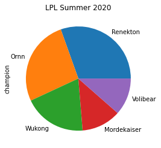

```python
lpl_top_data.champion.value_counts().nlargest(5).plot(kind='pie', title='LPL Summer 2020');
```

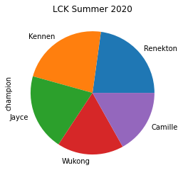

```python
lck_top_data.champion.value_counts().nlargest(5).plot(kind='pie', title='LCK Summer 2020');
```

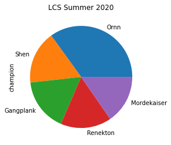

```python
lcs_top_data.champion.value_counts().nlargest(5).plot(kind='pie', title='LCS Summer 2020');
```

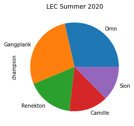

```python
lec_top_data.champion.value_counts().nlargest(5).plot(kind='pie', title='LEC Summer 2020');
```

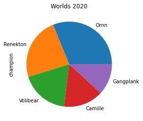

```python
worlds_data[worlds_data['position'] == 'top'].champion.value_counts().nlargest(5).plot(kind='pie', title='Worlds 2020');
```

## My thoughts

Immediately my eyes jumped to the LCS pie chart. Considering this graph showed the top five champion picks it was impressive that the four largest pieces of the pie all corresponded to champions that did not have a large carry presence. This is just another indicator that goes to show underutilized the top lane carry threat was in North America and as such it should have come as no surprise when they failed to play catchup to the radically different meta at worlds. If one takes a look at regions like LEC, or even LCK (the region LCS is notoriously influenced by), there is clearly a higher degree of willingness to flex into more primary carry threats as opposed to the LCS which seems highly focused on picking stable minded top lane champions. This definitely had a large part to play in the LCS teams getting baptized by fire, so to speak, on the world stage where there definitely was more of a focus on carry threat from the top lane then they were accustomed to.

Another thing that immediatley jumped out to me here was the Korean infatuation with Kennen, a pick that has historically been utilized to a proficient level by Korean top laners in the past (Smeb being one of the more famous ones that jump to mind), being heavily utilized by the LCK as it seemingly was a top 3 most played champion. Furthermore there was clearly a distinct difference between the value of Renekton when looking at the Eastern regions versus the West. Korea did not utilize it as much as the LPL but, perhaps due to the proximity of the regions and their willingness to scrim versus each other, definitely did utilize Renekton at a higher volume than LCS or LEC

## Looking at jungle champion picks across seasons and worlds

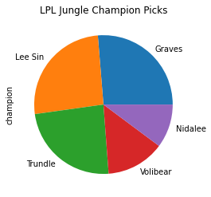

```python
lpl_jng_data.champion.value_counts().nlargest(5).plot(title="LPL Jungle Champion Picks", kind='pie');
```

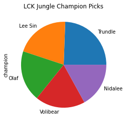

```python
lck_jng_data.champion.value_counts().nlargest(5).plot(title="LCK Jungle Champion Picks", kind='pie');
```

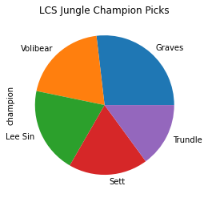

```python
lcs_jng_data.champion.value_counts().nlargest(5).plot(title="LCS Jungle Champion Picks", kind='pie');
```

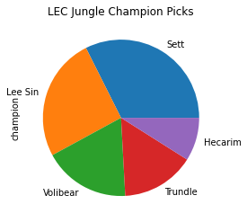

```python
lec_jng_data.champion.value_counts().nlargest(5).plot(title="LEC Jungle Champion Picks", kind='pie');
```

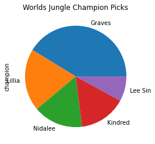

```python
worlds_data[worlds_data['position'] == 'jng'].champion.value_counts().nlargest(5).plot(title="Worlds Jungle Champion Picks", kind='pie');
```

## Looking at mid champion picks across seasons and worlds

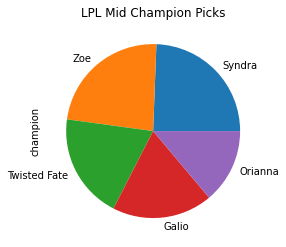

```python
lpl_mid_data.champion.value_counts().nlargest(5).plot(title='LPL Mid Champion Picks', kind='pie');
```

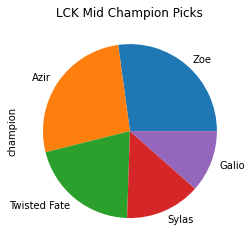

```python
lck_mid_data.champion.value_counts().nlargest(5).plot(title='LCK Mid Champion Picks', kind='pie');
```

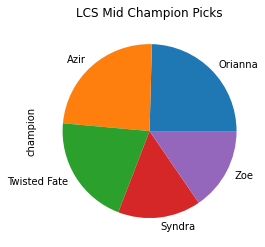

```python
lcs_mid_data.champion.value_counts().nlargest(5).plot(title='LCS Mid Champion Picks',kind='pie');
```

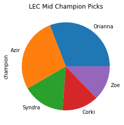

```python
lec_mid_data.champion.value_counts().nlargest(5).plot(title='LEC Mid Champion Picks',kind='pie');
```

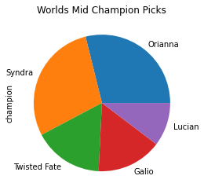

```python
worlds_data[worlds_data['position'] == 'mid'].champion.value_counts().nlargest(5).plot(title='Worlds Mid Champion Picks',kind='pie');
```

## My thoughts

One thing that comes as a bit of surprise was the fact that LCK was the only region that did not have Orianna, a long time staple, in their top 5 played during the regular season. Instead it seemed they heavily prioritized Sylas as a pick throughout the regular season. Despite that personally I doubt there would have been much trouble for them adapting to the worlds mid meta, as after all they might have broughten the deepest crop of mid laners, when compared to other regions, to worlds. Another interesting aspect that stood out to me was how underprioritized Zoe seemed to be at worlds, especially when compared to the regular season. Perhaps this was partially influenced by the carry jungle meta, as due to its ancillary effects the popularity of picks like Lucian shot up, as they synergized well with champs like Evelynn etc.

## Looking at Bot champion picks across seasons and worlds

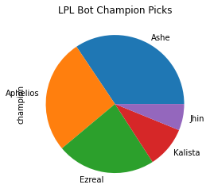

```python
lpl_bot_data.champion.value_counts().nlargest(5).plot(title='LPL Bot Champion Picks', kind='pie');
```

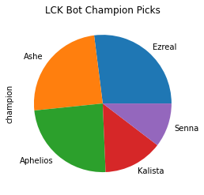

```python
lck_bot_data.champion.value_counts().nlargest(5).plot(title='LCK Bot Champion Picks', kind='pie');
```

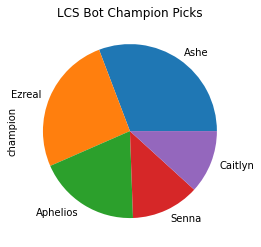

```python
lcs_bot_data.champion.value_counts().nlargest(5).plot(title='LCS Bot Champion Picks', kind='pie');
```

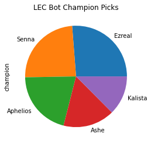

```python
lec_bot_data.champion.value_counts().nlargest(5).plot(title='LEC Bot Champion Picks', kind='pie');
```

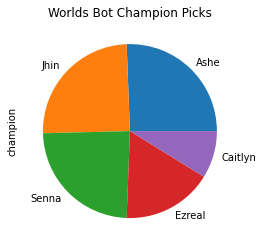

```python
worlds_data[worlds_data['position'] == 'bot'].champion.value_counts().nlargest(5).plot(title='Worlds Bot Champion Picks', kind='pie');
```

## My thoughts

As my eyes jumped to the other regions it became clear that they also had their own unique types of priorities on ADC's. Take LCK for an example, in comparison to LPL they had a far more equitable distribution of reliance across Aphelios, Ezreal, and Ashe. Furthermore when looking at LCS they had a whole different skew in their distribution of reliance, choosing to rely on Ashe and Ezreal at a higher rate than even the 200 year lord himself.

## Looking at Support champion picks across seasons and worlds

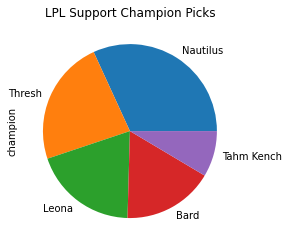

```python
lpl_sup_data.champion.value_counts().nlargest(5).plot(title='LPL Support Champion Picks', kind='pie');
```

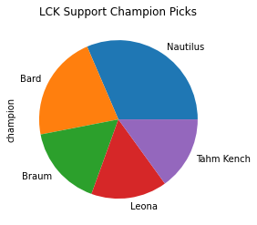

```python
lck_sup_data.champion.value_counts().nlargest(5).plot(title='LCK Support Champion Picks', kind='pie');
```

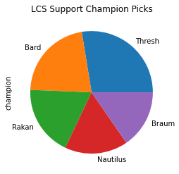

```python
lcs_sup_data.champion.value_counts().nlargest(5).plot(title='LCS Support Champion Picks', kind='pie');
```

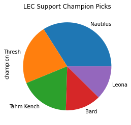

```python
lec_sup_data.champion.value_counts().nlargest(5).plot(title='LEC Support Champion Picks', kind='pie');
```

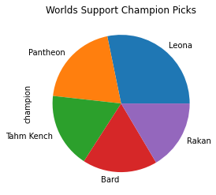

```python
worlds_data[worlds_data['position'] == 'sup'].champion.value_counts().nlargest(5).plot(title='Worlds Support Champion Picks', kind='pie');
```

## My thoughts

Other than that nothing particularly stood out. There was the Pantheon pick that rose in popularity during worlds, however that was a consequence of meta shifts and innovation coming out of the LCK region. I do have to admit that Damwon gaming was probably helped by the heavy presence of Pantheon within the meta, as Beryl was one of the best supports in the world on it.

# Game Length

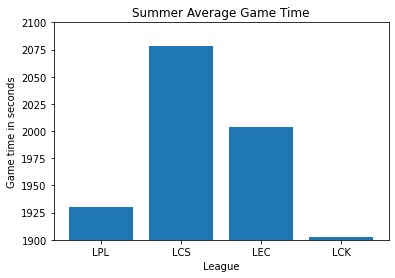

```python
ylabels= [lpl_summer_data['gamelength'].mean(), lcs_summer_data['gamelength'].mean(), lec_summer_data['gamelength'].mean(), lck_summer_data['gamelength'].mean()]
xlabels = ['LPL', 'LCS', 'LEC', 'LCK']
plt.bar(xlabels, ylabels);
plt.title("Summer Average Game Time")
x1,x2,y1,y2 = plt.axis()
plt.axis((x1,x2, 1900, 2100))
plt.xlabel('League');
plt.ylabel('Game time in seconds');
```

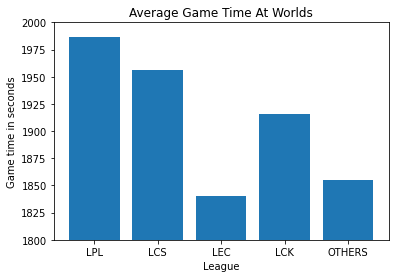

```python
ylabels= [chinese_data['gamelength'].mean(), na_data['gamelength'].mean(), eu_data['gamelength'].mean(), kr_data['gamelength'].mean(), other_data['gamelength'].mean()]
xlabels = ['LPL', 'LCS', 'LEC', 'LCK', 'OTHERS']
plt.bar(xlabels, ylabels);
x1,x2,y1,y2 = plt.axis()
plt.axis((x1,x2, 1800, 2000))
plt.title("Average Game Time At Worlds")
plt.xlabel('League');
plt.ylabel('Game time in seconds');
```

## My Thoughts

# KDA

```python
kda = lambda row: (row['kills'] + row['assists']) / row['deaths'] if row['deaths'] > 0 else 99999
```

```python
lcs_top_data['kda'] = lcs_top_data.apply(kda, axis = 1)
lcs_jng_data['kda'] = lcs_jng_data.apply(kda, axis = 1)
lcs_mid_data['kda'] = lcs_mid_data.apply(kda, axis = 1)
lcs_bot_data['kda'] = lcs_bot_data.apply(kda, axis = 1)
lcs_sup_data['kda'] = lcs_sup_data.apply(kda, axis = 1)
```

```python
lpl_top_data['kda'] = lpl_top_data.apply(kda, axis = 1)
lpl_jng_data['kda'] = lpl_jng_data.apply(kda, axis = 1)
lpl_mid_data['kda'] = lpl_mid_data.apply(kda, axis = 1)
lpl_bot_data['kda'] = lpl_bot_data.apply(kda, axis = 1)
lpl_sup_data['kda'] = lpl_sup_data.apply(kda, axis = 1)
```

```python
lck_top_data['kda'] = lck_top_data.apply(kda, axis = 1)
lck_jng_data['kda'] = lck_jng_data.apply(kda, axis = 1)
lck_mid_data['kda'] = lck_mid_data.apply(kda, axis = 1)
lck_bot_data['kda'] = lck_bot_data.apply(kda, axis = 1)
lck_sup_data['kda'] = lck_sup_data.apply(kda, axis = 1)
```

```python
lec_top_data['kda'] = lec_top_data.apply(kda, axis = 1)
lec_jng_data['kda'] = lec_jng_data.apply(kda, axis = 1)
lec_mid_data['kda'] = lec_mid_data.apply(kda, axis = 1)
lec_bot_data['kda'] = lec_bot_data.apply(kda, axis = 1)
lec_sup_data['kda'] = lec_sup_data.apply(kda, axis = 1)
```

## Distribution of top laner KDA's

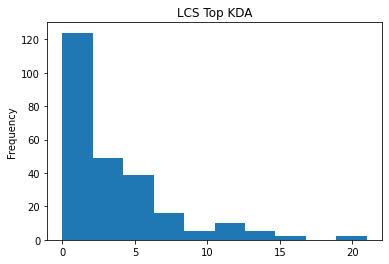

```python
lcs_top_data[lcs_top_data['kda'] < 10000]['kda'].plot(title='LCS Top KDA', kind='hist');
```

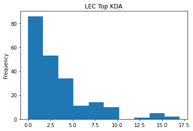

```python
lec_top_data[lec_top_data['kda'] < 10000]['kda'].plot(title='LEC Top KDA', kind='hist');
```

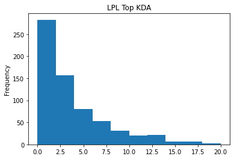

```python
lpl_top_data[lpl_top_data['kda'] < 10000]['kda'].plot(title='LPL Top KDA', kind='hist');
```

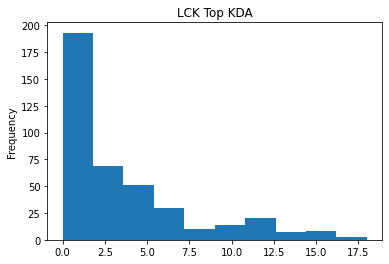

```python
lck_top_data[lck_top_data['kda'] < 10000]['kda'].plot(title='LCK Top KDA', kind='hist');
```